# National Parks Camper

How far ahead of time do I need to reserve a campsite?

Nathan Hoteling

1/26/2021

## Raw data and pre-processing

Data were downloaded from the [Recreation Information Database](https://ridb.recreation.gov/) (RIDB), hosted by Recreation.gov [here](https://ridb.recreation.gov/download). RIDB offers an API for data access, however annual reservations data are available as raw CSV files for dates from 2006 through 2019. The files are quite large, at >1GB per year and more than 3M reservations, so pre-processing can be fairly time-consuming. There are also several supplemental files that list and define various attributes in the data.

Cleaning and pre-processing are carried out over four distinct phases:  
1. Convert raw CSV file to binary RDS for faster reading later with R  
2. Filter reservations data to NPS and USFS, adjust variable names and types  
3. Process reservations data into daily tallies for each facility over the course of the year  
4. Read and process auxiliary files with campsite meta-data

## Exploratory plots

### Filled fraction

The plot below shows the fraction of campsites reserved for each park, aggregated by week. Several panels show a flat-line pattern less than 1.0, since not all campsites are reservable ahead of time. For example, in Canyonlands National Park, only “loop B” sites are reservable, whereas “loop A” sites are operated on a first-come, first-served basis. This amounts to around half of the total sites.

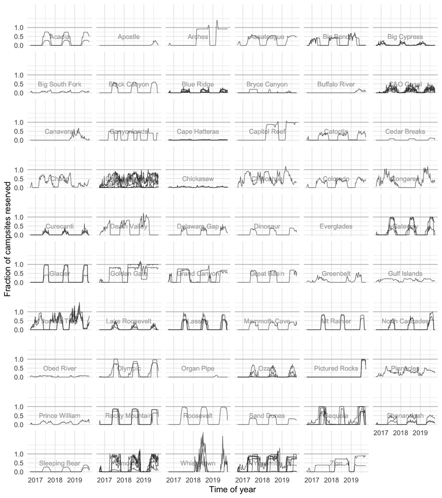

### Planning Window

The plots below show the typical planning window, defined as the median number of days ahead of time that campsite reservations are typically made over the course of the year. The maximum planning window varies by park, but it generally does not exceed around six months. A flat-top pattern is seen for locations that are in particularly high demand; these sites fill up at or near the date that they become available. For example, in Zion National Park sites are made available on a 14-day rolling basis and they fill up almost immediately. Similarly, campsites at Apostle Islands are made available on a 30-day rolling basis and also fill up very quickly.

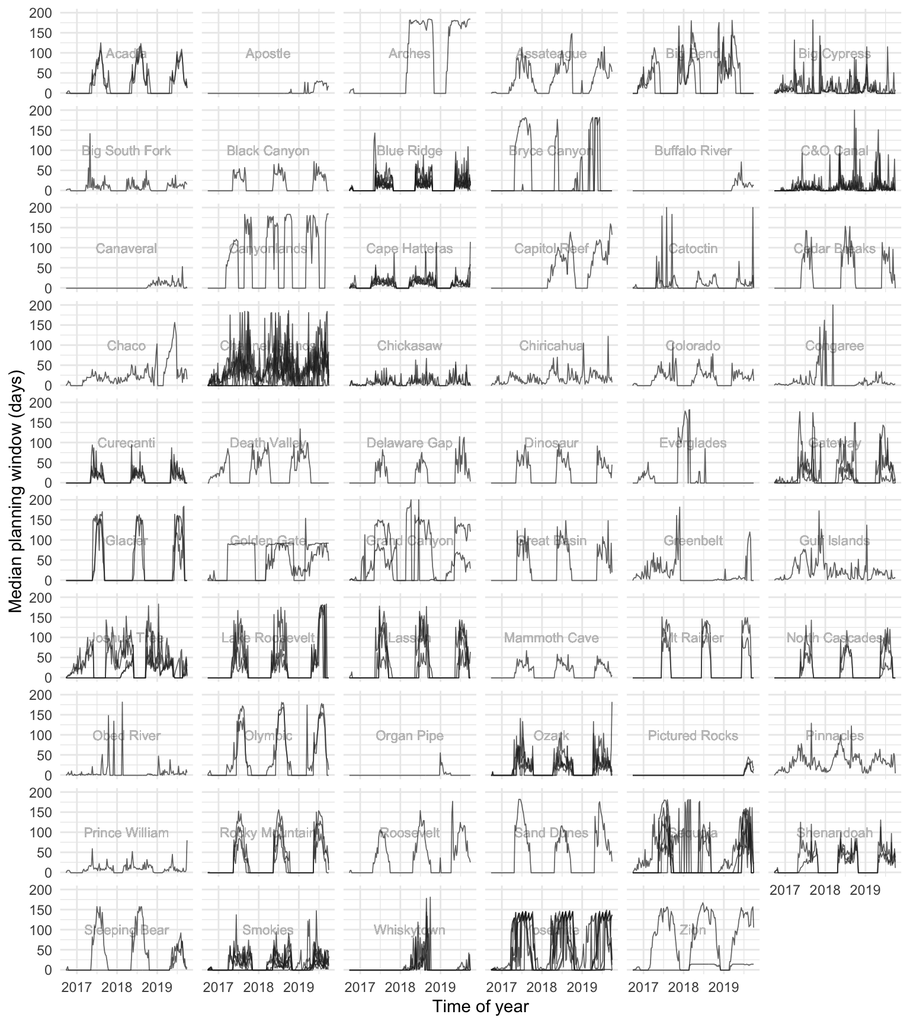

### Campsite demand

We can combine the two variables plotted above into a single metric called **demand** as a means to represent the desireablility of a particular location for camping. This metric is defined as the product of the normalized planning window and the fraction of reservable campsites filled. Here, we refer to the normalized planning window as the median planning window divided by the maximum planning window; for example, in the case of Zion National Park campsites are made available on a rolling 14-day window. Since these fill up almost immediately, median planning window is 14 days and the normalized value is 14/14 = 1.0. As such, the demand can take on values between 0 and 1.

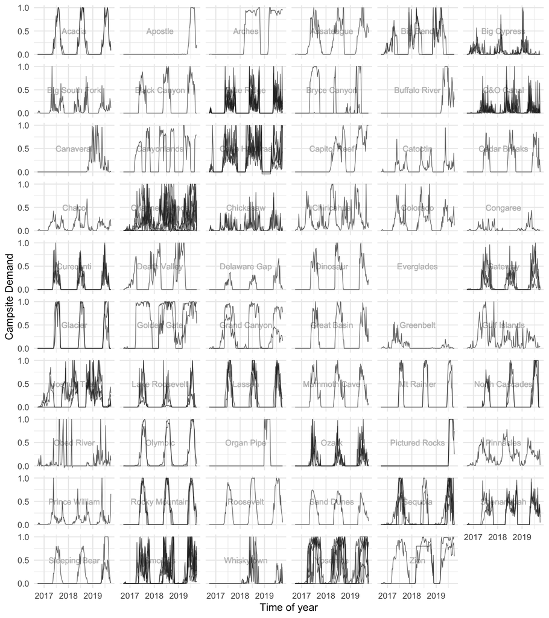